# White wine quality

# Introduction

In this project i choose to work with **white wine quality** dataset. White wine is a wine whose color can be straw-yellow, yellow-green or yellow-gold.It is produced by the alcoholic fermentation of the non-coloured pulp of the grapes, which may have a skin of any color. It is very difficult to assess the quality of wine by reading label. Quality is assessed best by tasting. Quite often you won’t be able to taste a wine before buying, but information is available on wine lables to help you decide, although you will need a certain amount of the knowledge about the contents of the wine in prior.

# Univariate Plot Section

```
## [1] 4898   12
```

```
## 'data.frame':    4898 obs. of  12 variables:
##  $ fixed.acidity       : num  7 6.3 8.1 7.2 7.2 8.1 6.2 7 6.3 8.1 ...
##  $ volatile.acidity    : num  0.27 0.3 0.28 0.23 0.23 0.28 0.32 0.27 0.3 0.22 ...
##  $ citric.acid         : num  0.36 0.34 0.4 0.32 0.32 0.4 0.16 0.36 0.34 0.43 ...
##  $ residual.sugar      : num  20.7 1.6 6.9 8.5 8.5 6.9 7 20.7 1.6 1.5 ...
##  $ chlorides           : num  0.045 0.049 0.05 0.058 0.058 0.05 0.045 0.045 0.049 0.044 ...
##  $ free.sulfur.dioxide : num  45 14 30 47 47 30 30 45 14 28 ...
##  $ total.sulfur.dioxide: num  170 132 97 186 186 97 136 170 132 129 ...
##  $ density             : num  1.001 0.994 0.995 0.996 0.996 ...
##  $ pH                  : num  3 3.3 3.26 3.19 3.19 3.26 3.18 3 3.3 3.22 ...
##  $ sulphates           : num  0.45 0.49 0.44 0.4 0.4 0.44 0.47 0.45 0.49 0.45 ...
##  $ alcohol             : num  8.8 9.5 10.1 9.9 9.9 10.1 9.6 8.8 9.5 11 ...
##  $ quality             : int  6 6 6 6 6 6 6 6 6 6 ...
```

There are 4898 observation and 12 varaiables to denote the composition and quality of white wine. From 12 of the variable 11 of them are numeric datatype and an integer to denote the quality of wine.

**alcohol**

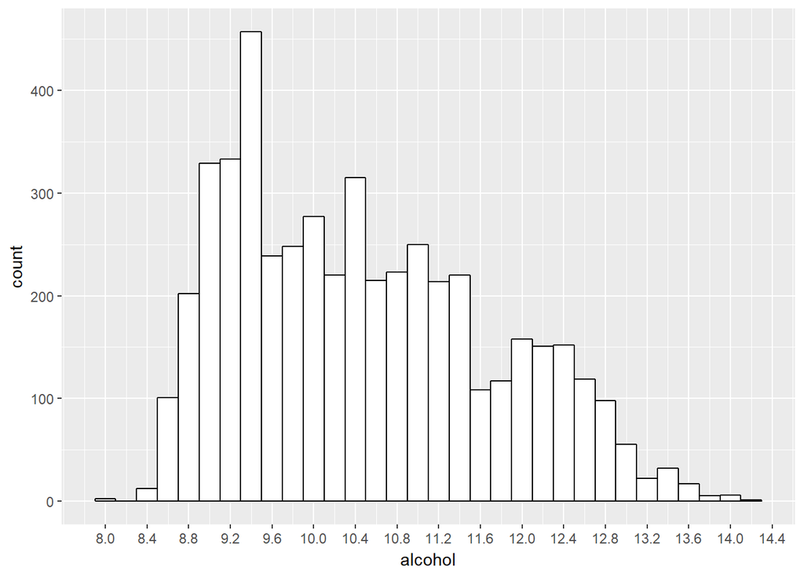

```
##    Min. 1st Qu.  Median    Mean 3rd Qu.    Max.
##    8.00    9.50   10.40   10.51   11.40   14.20
```

In normal most of the white wine can have a alcohol content ranging from 5%-15%. In this dataset the alcohol content ranging from 8% to 14.20% and 50% of the wines are below 10.40% alcohol content.

**residual sugar**

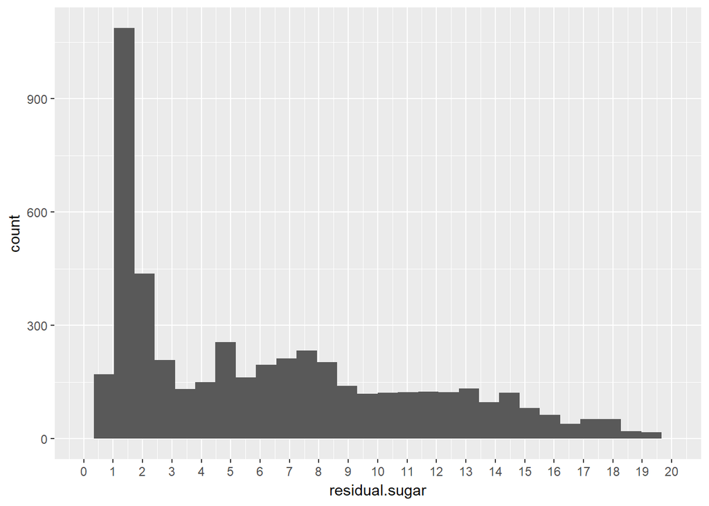

```
##    Min. 1st Qu.  Median    Mean 3rd Qu.    Max.
##   0.600   1.700   5.200   6.391   9.900  65.800
```

Residual sugars are the sugars that are not converted into alcohol during fermentation. Residual sugar in wines ranges from 0 to 220 grams per liter sugar depanding on the style. Here it ranges from 0.600 to 65.800 with half of the wines fall below 5.200 and 75% of the wines have less than 9.900 residual sugar. Less than 25% wines have residual sugar greater than 10.0.

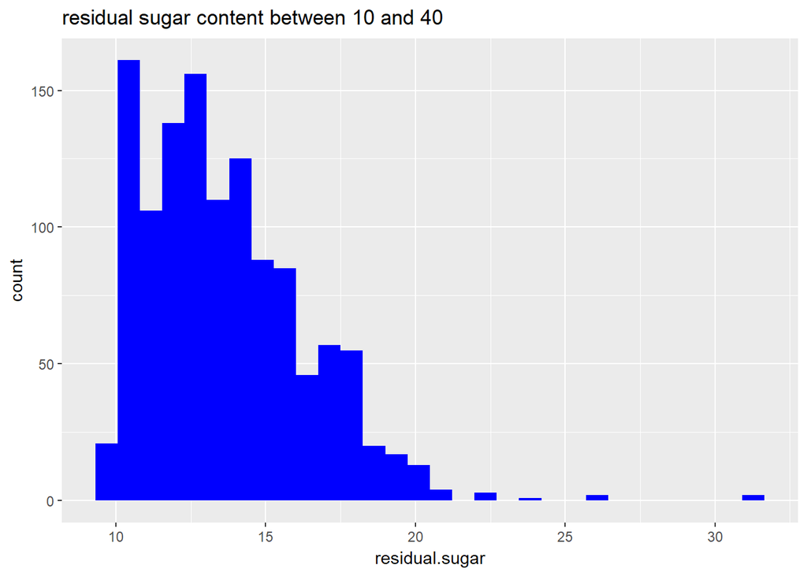